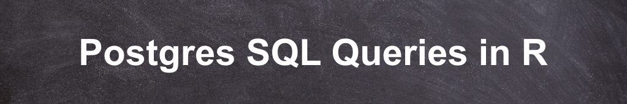

### Introduction

This tutorial explains how to query a Postgres SQL database in R on an OSX system. In most instances where SQL queries are being performed, data—usually a set of relations, are being selected from an external database hosting the data. But with no access to a server a Postgres SQL database can be created locally on your own hard drive, which is the approach used in this example. However, if you have access to an external server you can of course use that instead. Otherwise follow this [tutorial](https://www.codementor.io/devops/tutorial/getting-started-postgresql-server-mac-osx) that explains how to download and create a Postgres SQL database on your own machine.

The dataset that we will be analyzing is fictitious and deals with album ratings of new wave 80’s music. The 3 relations are stored in csv files that should be saved into your working directory (links on previous page). We begin by loading the ‘RPostgreSQL’ package. If not yet installed, first run `install.package(“RPostgreSQL”)` followed by `library(RPostgreSQL)`. Then set your working directory with `setwd()` to the location that you will be working from.

```r
library(RPostgreSQL)
setwd("~/Documents/R_SQL/New_Wave_80s/")
```

Using `read.csv()` we load the data relations that will eventually be saved into our local database. The csv files contain fictitious data regarding new wave 80’s albums and critic/reviewer ratings.

```r
album_data <- read.csv("album.csv")
rating_data <- read.csv("ratings.csv")
reviewers_data <- read.csv("reviewers.csv")
```

Next we load the ‘knitr’, and ‘kableExtra’ packages that make HTML-like tables to display our relations. We also load the ‘dplyr’ package for use of the piping function %>%, and with the `options()` function we are able to display the table in HTML format.

### Relations

##### Album

- **album_id**: the unique identifier for each album rated.
- **title**: the title of the album.
- **year**: the year the album was released.
- **artist**: the artist of the album.

| album_id | title | year | artist |
| --- | --- | --- | --- |
| 1001 | When In Rome (self titled) | 1988 | When In Rome |
| 1002 | After the Snow | 1982 | Modern English |
| 1003 | Songs From The Big Chair | 1985 | Tears For Fears |
| 1004 | Rio | 1982 | Duran Duran |
| 1005 | Once Upon A Time | 1985 | Simple Minds |
| 1006 | Black Celebration | 1986 | Depeche Mode |
| 1007 | Brotherhood | 1986 | New Order |
| 1008 | Shuttered Room | 1982 | The Fixx |
| 1009 | Hunting High And Low | 1985 | A-Ha |

##### Rating

- **reviewer_id**: the unique identifier for each reviewer that gave a rating.
- **album_id**: the unique identifier for each album rated.
- **rating**: value ranging from 1-10, with 1 being the least favorable rating and 10 being the most favorable.
- **season**: the season when the reviewer gave the rating.

| reviewer_id | album_id | rating | season |
| --- | --- | --- | --- |
| 2001 | 1001 | 6 | Summer |
| 2001 | 1005 | 5 | Winter |
| 2002 | 1004 | 7 | Spring |
| 2002 | 1008 | 8 | Spring |
| 2003 | 1006 | 9 | Fall |
| 2003 | 1002 | 6 | Fall |
| 2003 | 1003 | 8 | Summer |
| 2004 | 1005 | 7 | Winter |
| 2005 | 1007 | 4 | Winter |
| 2005 | 1009 | 10 | Spring |
| 2006 | 1007 | 8 | Summer |
| 2006 | 1009 | 7 | Fall |
| 2007 | 1001 | 7 | Spring |
| 2007 | 1002 | 9 | Winter |

##### Reviewers

- **reviewer_id**: the unique identifier for each reviewer that gave a rating.
- **name**: the first and last name of the reviewer.

| reviewer_id | name |
| --- | --- |
| 2001 | Amy Sanchez |
| 2002 | Mark Schilling |
| 2003 | Richard Price |
| 2004 | Javier Perez |
| 2005 | Maria Thomson |
| 2006 | Socrates Soto |
| 2007 | Melinda Lee |

### Database Connection

To connect to the database you will need these 4 pieces of information:

1. The name of the server hosting the database.
2. Your username for the database.
3. Your password for using the database.
4. The name of the database.

In the code below we use `PostgreSQL()` and enter it as a parameter into `dbConnect()`, along with several other parameters. The first of these is ‘host’, which points the connection to the database being accessed. Then ‘localhost’ is used to indicate that the host database is on the local hard drive. If accessing a database from an external server, the url of the database would instead be inserted here. Then there is the user name—enter yours accordingly. And of course there is the password and the name of the database that is entered in the last 2 parameters.

```r
con <- dbConnect(PostgreSQL(), host="localhost", user= "matthew",
                 password="---------", dbname="super_awesome_application")
```

With the connection open we can now insert the 3 relations into the database using `dbWriteTable()`. The first parameter refers to the connection we defined, and the second parameter is the name used for the relation in the database. The third parameter is of course the actual data.

```r
dbWriteTable(con, "album", album_data)
dbWriteTable(con, "rating", rating_data)
dbWriteTable(con, "reviewers", reviewers_data)
```

With the relations saved we may now conduct SQL queries.

### SQL

The `dbGetQuery()` function enables R to query the database. The first parameter is con—the database connection followed by the actual SQL query placed within quotes.

#### Query 1

Produce a data frame that contains all of the album ratings, except for those rated during the Winter season.

```r
df_query1 <- dbGetQuery(con, "SELECT *
                              From rating
                              WHERE season <> 'Winter'")
df_query1
```

```
##    row.names reviewer_id album_id rating season
## 1          1        2001     1001      6 Summer
## 2          3        2002     1004      7 Spring
## 3          4        2002     1008      8 Spring
## 4          5        2003     1006      9   Fall
## 5          6        2003     1002      6   Fall
## 6          7        2003     1003      8 Summer
## 7         10        2005     1009     10 Spring
## 8         11        2006     1007      8 Summer
## 9         12        2006     1009      7   Fall
## 10        13        2007     1001      7 Spring
```

#### Query 2

Produce a data frame containing all of the albums produced before 1988 that had a rating of 6 or lower. And the final relation should only contain 5 pieces of information—the title of the album, the year it was released, the album’s artist, the album’s rating, and the season in which it was rated.

```r
df_query2 <- dbGetQuery(con, "SELECT title, year, artist, rating, season
                              FROM album
                              INNER JOIN rating
                              ON album.album_id = rating.album_id
                              WHERE year < 1988
                              AND rating <= 6")
df_query2
```

```
##              title year         artist rating season
## 1 Once Upon A Time 1985   Simple Minds      5 Winter
## 2   After the Snow 1982 Modern English      6   Fall
## 3      Brotherhood 1986      New Order      4 Winter
```

#### Query 3

```r
df_query3 <- dbGetQuery(con, "SELECT title, year, artist, name, rating
                              FROM album
                              INNER JOIN rating
                              ON album.album_id = rating.album_id
                              INNER JOIN reviewers
                              ON rating.reviewer_id = reviewers.reviewer_id
                              WHERE album.year > 1984
                              AND reviewers.name <> 'Socrates Soto'
                              ORDER BY album.title")
df_query3
```

```
##                        title year          artist          name rating
## 1          Black Celebration 1986    Depeche Mode Richard Price      9
## 2                Brotherhood 1986       New Order Maria Thomson      4
## 3       Hunting High And Low 1985            A-Ha Maria Thomson     10
## 4           Once Upon A Time 1985    Simple Minds   Amy Sanchez      5
## 5           Once Upon A Time 1985    Simple Minds  Javier Perez      7
## 6   Songs From The Big Chair 1985 Tears For Fears Richard Price      8
## 7 When In Rome (self titled) 1988    When In Rome   Melinda Lee      7
## 8 When In Rome (self titled) 1988    When In Rome   Amy Sanchez      6
```

### Summary

As you can see, once the database is setup it is rather easy to conduct queries using `dbGetQuery()`. What I find most helpful about practicing SQL queries in this manner is that it allows you to practice without having access to an external server, which is what you will be querying from in an industry setting. Once you are there, you can use these same R codes. Thanks for following along—I hope this was helpful!

[figure not shown]